# IE_582_HW3_CelilMumcu

```r
library(CRANsearcher)
library(MASS)
library(ggplot2)
library(data.table)
library(readxl)
```

## View(ConsumptionData)

```r
ConsumptionData <- read_excel("/Users/ASUS/Documents/GercekZamanliTuketim-01012016-29112019.xls")
##View(ConsumptionData)
```

```r
str(ConsumptionData)
```

```
## Classes 'tbl_df', 'tbl' and 'data.frame':    34272 obs. of  5 variables:
##  $ Bir        : chr  "01.01.2016" "01.01.2016" "01.01.2016" "01.01.2016" ...
##  $ Ä°ki        : chr  "00:00" "01:00" "02:00" "03:00" ...
##  $ Consumption: num  26277 24992 23533 22465 22003 ...
##  $ Lag_48     : num  NA NA NA NA NA NA NA NA NA NA ...
##  $ Lag_168    : num  NA NA NA NA NA NA NA NA NA NA ...
```

## MAPE percentage error calculation, smaller MAPE means better forecast

```r
MAPE <- function(actual, forecast){
  maperesult= sum((abs(actual-forecast)/actual)*100)/length(actual)
  return(maperesult)
}
```

```r
length(ConsumptionData$Consumption)
```

```
## [1] 34272
```

```r
trainingdata= ConsumptionData[1:(length(ConsumptionData$Consumption)-29*24),]
testingdata= ConsumptionData[(length(ConsumptionData$Consumption)-29*24+1):34262,]
```

## there is no consumption value in the some hours of last day, to prevent the conflict i wrote 34262 manually.

```r
## View(testingdata)
## View(trainingdata)
MAPE48= MAPE(testingdata$Consumption,testingdata$Lag_48)
MAPE48
```

```
## [1] 7.630677
```

```r
MAPE168= MAPE(testingdata$Consumption,testingdata$Lag_168)
MAPE168
```

```
## [1] 3.053922
```

## in the Lag_48 and Lag_168 columns there are missing values naturally, i will omit first 168 row to make the table without NA value to prevent problems in regressions

## View(trainingdata)

```r
trainingdataclear= trainingdata[169:length(trainingdata$Consumption),]
##View(trainingdataclear)
```

## for the second part, i am going to try to create a linear regression by taking two requested features into account as time series analysis

```r
LinearRegressionModel= lm(Consumption~ Lag_48 + Lag_168, trainingdataclear)
summary(LinearRegressionModel)
```

```
##
## Call:
## lm(formula = Consumption ~ Lag_48 + Lag_168, data = trainingdataclear)
##
## Residuals:
##      Min       1Q   Median       3Q      Max
## -16784.6   -994.2      2.9   1022.4  15951.4
##
## Coefficients:
##              Estimate Std. Error t value Pr(>|t|)
## (Intercept) 1.624e+03  9.678e+01   16.78   <2e-16 ***
## Lag_48      3.257e-01  3.520e-03   92.51   <2e-16 ***
## Lag_168     6.246e-01  3.518e-03  177.51   <2e-16 ***
## ---
## Signif. codes:  0 '***' 0.001 '**' 0.01 '*' 0.05 '.' 0.1 ' ' 1
##
## Residual standard error: 2403 on 33405 degrees of freedom
## Multiple R-squared:  0.7627, Adjusted R-squared:  0.7627
## F-statistic: 5.368e+04 on 2 and 33405 DF,  p-value: < 2.2e-16
```

```r
ForecastLinearRegressionModel= predict(LinearRegressionModel, testingdata)
MAPEpartB= MAPE(testingdata$Consumption, ForecastLinearRegressionModel)
MAPEpartB
```

```
## [1] 3.872783
```

## View(trainingdataclear) 33408 rows 33408/24= 1392 days

## View(testingdata) 686 rows but last 14 days doesnt make a total day, so (686-14)/24= 28 whole days + 14 hours

## for the third part, every consecutive 24 hours sum up the one day interval, (it begins at 00:00 finishes at 23:00 for training)

## i took different types of errors i dont know why, that’s why i assigned hourly data via a long way as below:

## i’ll train linear regression models for each hour using the same training period

```r
for(i in 1:1392) {
  trainingdataHourzero= trainingdataclear[1+24*(i-1),]
}
for(i in 1:1392) {
  trainingdataHourzero[i,]= trainingdataclear[1+24*(i-1),]
}
for(i in 1:1392) {
  trainingdataHour1= trainingdataclear[2+24*(i-1),]
}
for(i in 1:1392) {
  trainingdataHour1[i,]= trainingdataclear[2+24*(i-1),]
}
for(i in 1:1392) {
  trainingdataHour2= trainingdataclear[3+24*(i-1),]
}
for(i in 1:1392) {
  trainingdataHour2[i,]= trainingdataclear[3+24*(i-1),]
}
for(i in 1:1392) {
  trainingdataHour3= trainingdataclear[4+24*(i-1),]
}
for(i in 1:1392) {
  trainingdataHour3[i,]= trainingdataclear[4+24*(i-1),]
}
for(i in 1:1392) {
  trainingdataHour4= trainingdataclear[5+24*(i-1),]
}
for(i in 1:1392) {
  trainingdataHour4[i,]= trainingdataclear[5+24*(i-1),]
}
for(i in 1:1392) {
  trainingdataHour5= trainingdataclear[6+24*(i-1),]
}
for(i in 1:1392) {
  trainingdataHour5[i,]= trainingdataclear[6+24*(i-1),]
}
for(i in 1:1392) {
  trainingdataHour6= trainingdataclear[7+24*(i-1),]
}
for(i in 1:1392) {
  trainingdataHour6[i,]= trainingdataclear[7+24*(i-1),]
}
for(i in 1:1392) {
  trainingdataHour7= trainingdataclear[8+24*(i-1),]
}
for(i in 1:1392) {
  trainingdataHour7[i,]= trainingdataclear[8+24*(i-1),]
}
for(i in 1:1392) {
  trainingdataHour8= trainingdataclear[9+24*(i-1),]
}
for(i in 1:1392) {
  trainingdataHour8[i,]= trainingdataclear[9+24*(i-1),]
}
for(i in 1:1392) {
  trainingdataHour9= trainingdataclear[10+24*(i-1),]
}
for(i in 1:1392) {
  trainingdataHour9[i,]= trainingdataclear[10+24*(i-1),]
}
for(i in 1:1392) {
  trainingdataHour10= trainingdataclear[11+24*(i-1),]
}
for(i in 1:1392) {
  trainingdataHour10[i,]= trainingdataclear[11+24*(i-1),]
}
for(i in 1:1392) {
  trainingdataHour11= trainingdataclear[12+24*(i-1),]
}
for(i in 1:1392) {
  trainingdataHour11[i,]= trainingdataclear[12+24*(i-1),]
}
for(i in 1:1392) {
  trainingdataHour12= trainingdataclear[13+24*(i-1),]
}
for(i in 1:1392) {
  trainingdataHour12[i,]= trainingdataclear[13+24*(i-1),]
}
for(i in 1:1392) {
  trainingdataHour13= trainingdataclear[14+24*(i-1),]
}
for(i in 1:1392) {
  trainingdataHour13[i,]= trainingdataclear[14+24*(i-1),]
}
for(i in 1:1392) {
  trainingdataHour14= trainingdataclear[15+24*(i-1),]
}
for(i in 1:1392) {
  trainingdataHour14[i,]= trainingdataclear[15+24*(i-1),]
}
for(i in 1:1392) {
  trainingdataHour15= trainingdataclear[16+24*(i-1),]
}
for(i in 1:1392) {
  trainingdataHour15[i,]= trainingdataclear[16+24*(i-1),]
}
for(i in 1:1392) {
  trainingdataHour16= trainingdataclear[17+24*(i-1),]
}
for(i in 1:1392) {
  trainingdataHour16[i,]= trainingdataclear[17+24*(i-1),]
}
for(i in 1:1392) {
  trainingdataHour17= trainingdataclear[18+24*(i-1),]
}
for(i in 1:1392) {
  trainingdataHour17[i,]= trainingdataclear[18+24*(i-1),]
}
for(i in 1:1392) {
  trainingdataHour18= trainingdataclear[19+24*(i-1),]
}
for(i in 1:1392) {
  trainingdataHour18[i,]= trainingdataclear[19+24*(i-1),]
}
for(i in 1:1392) {
  trainingdataHour19= trainingdataclear[20+24*(i-1),]
}
for(i in 1:1392) {
  trainingdataHour19[i,]= trainingdataclear[20+24*(i-1),]
}
for(i in 1:1392) {
  trainingdataHour20= trainingdataclear[21+24*(i-1),]
}
for(i in 1:1392) {
  trainingdataHour20[i,]= trainingdataclear[21+24*(i-1),]
}
for(i in 1:1392) {
  trainingdataHour21= trainingdataclear[22+24*(i-1),]
}
for(i in 1:1392) {
  trainingdataHour21[i,]= trainingdataclear[22+24*(i-1),]
}
for(i in 1:1392) {
  trainingdataHour22= trainingdataclear[23+24*(i-1),]
}
for(i in 1:1392) {
  trainingdataHour22[i,]= trainingdataclear[23+24*(i-1),]
}
for(i in 1:1392) {
  trainingdataHour23= trainingdataclear[24+24*(i-1),]
}
for(i in 1:1392) {
  trainingdataHour23[i,]= trainingdataclear[24+24*(i-1),]
}
```

## for testing Hours

```r
for(i in 1:29) {
  testingdataHourzero= testingdata[1+24*(i-1),]
}
for(i in 1:29) {
  testingdataHourzero[i,]= testingdata[1+24*(i-1),]
}
for(i in 1:29) {
  testingdataHour1= testingdata[2+24*(i-1),]
}
for(i in 1:29) {
  testingdataHour1[i,]= testingdata[2+24*(i-1),]
}
for(i in 1:29) {
  testingdataHour2= testingdata[3+24*(i-1),]
}
for(i in 1:29) {
  testingdataHour2[i,]= testingdata[3+24*(i-1),]
}
for(i in 1:29) {
  testingdataHour3= testingdata[4+24*(i-1),]
}
for(i in 1:29) {
  testingdataHour3[i,]= testingdata[4+24*(i-1),]
}
for(i in 1:29) {
  testingdataHour4= testingdata[5+24*(i-1),]
}
for(i in 1:29) {
  testingdataHour4[i,]= testingdata[5+24*(i-1),]
}
for(i in 1:29) {
  testingdataHour5= testingdata[6+24*(i-1),]
}
for(i in 1:29) {
  testingdataHour5[i,]= testingdata[6+24*(i-1),]
}
for(i in 1:29) {
  testingdataHour6= testingdata[7+24*(i-1),]
}
for(i in 1:29) {
  testingdataHour6[i,]= testingdata[7+24*(i-1),]
}
for(i in 1:29) {
  testingdataHour7= testingdata[8+24*(i-1),]
}
for(i in 1:29) {
  testingdataHour7[i,]= testingdata[8+24*(i-1),]
}
for(i in 1:29) {
  testingdataHour8= testingdata[9+24*(i-1),]
}
for(i in 1:29) {
  testingdataHour8[i,]= testingdata[9+24*(i-1),]
}
for(i in 1:29) {
  testingdataHour9= testingdata[10+24*(i-1),]
}
for(i in 1:29) {
  testingdataHour9[i,]= testingdata[10+24*(i-1),]
}
for(i in 1:29) {
  testingdataHour10= testingdata[11+24*(i-1),]
}
for(i in 1:29) {
  testingdataHour10[i,]= testingdata[11+24*(i-1),]
}
for(i in 1:29) {
  testingdataHour11= testingdata[12+24*(i-1),]
}
for(i in 1:29) {
  testingdataHour11[i,]= testingdata[12+24*(i-1),]
}
for(i in 1:29) {
  testingdataHour12= testingdata[13+24*(i-1),]
}
for(i in 1:29) {
  testingdataHour12[i,]= testingdata[13+24*(i-1),]
}
for(i in 1:29) {
  testingdataHour13= testingdata[14+24*(i-1),]
}
for(i in 1:29) {
  testingdataHour13[i,]= testingdata[14+24*(i-1),]
}
for(i in 1:28) {
  testingdataHour14= testingdata[15+24*(i-1),]
}
for(i in 1:28) {
  testingdataHour14[i,]= testingdata[15+24*(i-1),]
}
for(i in 1:28) {
  testingdataHour15= testingdata[16+24*(i-1),]
}
for(i in 1:28) {
  testingdataHour15[i,]= testingdata[16+24*(i-1),]
}
for(i in 1:28) {
  testingdataHour16= testingdata[17+24*(i-1),]
}
for(i in 1:28) {
  testingdataHour16[i,]= testingdata[17+24*(i-1),]
}
for(i in 1:28) {
  testingdataHour17= testingdata[17+24*(i-1),]
}
for(i in 1:28) {
  testingdataHour17[i,]= testingdata[17+24*(i-1),]
}
for(i in 1:28) {
  testingdataHour18= testingdata[18+24*(i-1),]
}
for(i in 1:28) {
  testingdataHour18[i,]= testingdata[18+24*(i-1),]
}
for(i in 1:28) {
  testingdataHour19= testingdata[19+24*(i-1),]
}
for(i in 1:28) {
  testingdataHour19[i,]= testingdata[19+24*(i-1),]
}
for(i in 1:28) {
  testingdataHour20= testingdata[20+24*(i-1),]
}
for(i in 1:28) {
  testingdataHour20[i,]= testingdata[20+24*(i-1),]
}
for(i in 1:28) {
  testingdataHour21= testingdata[21+24*(i-1),]
}
for(i in 1:28) {
  testingdataHour21[i,]= testingdata[21+24*(i-1),]
}
for(i in 1:28) {
  testingdataHour22= testingdata[22+24*(i-1),]
}
for(i in 1:28) {
  testingdataHour22[i,]= testingdata[22+24*(i-1),]
}
for(i in 1:28) {
  testingdataHour23= testingdata[23+24*(i-1),]
}
for(i in 1:28) {
  testingdataHour23[i,]= testingdata[23+24*(i-1),]
}
```

```r
LinearRegressionModelHourzero= lm(Consumption~ Lag_48 + Lag_168, trainingdataHourzero)
summary(LinearRegressionModelHourzero)
```

```
##
## Call:
## lm(formula = Consumption ~ Lag_48 + Lag_168, data = trainingdataHourzero)
##
## Residuals:
##     Min      1Q  Median      3Q     Max
## -9082.4  -773.8    41.5   867.9  6257.5
##
## Coefficients:
##              Estimate Std. Error t value Pr(>|t|)
## (Intercept) 2.395e+03  5.078e+02   4.717 2.63e-06 ***
## Lag_48      5.028e-01  1.912e-02  26.291  < 2e-16 ***
## Lag_168     4.199e-01  1.911e-02  21.973  < 2e-16 ***
## ---
## Signif. codes:  0 '***' 0.001 '**' 0.01 '*' 0.05 '.' 0.1 ' ' 1
##
## Residual standard error: 1604 on 1389 degrees of freedom
## Multiple R-squared:  0.6971, Adjusted R-squared:  0.6967
## F-statistic:  1599 on 2 and 1389 DF,  p-value: < 2.2e-16
```

```r
ForecastLinearRegressionModelHourzero= predict(LinearRegressionModelHourzero, testingdataHourzero)
MAPEHourzero= MAPE(testingdataHourzero$Consumption, ForecastLinearRegressionModelHourzero)
```

```r
LinearRegressionModelHour1= lm(Consumption~ Lag_48 + Lag_168, trainingdataHour1)
summary(LinearRegressionModelHour1)
```

```
##
## Call:
## lm(formula = Consumption ~ Lag_48 + Lag_168, data = trainingdataHour1)
##
## Residuals:
##     Min      1Q  Median      3Q     Max
## -9307.9  -757.9    67.0   835.0  6324.2
##
## Coefficients:
##              Estimate Std. Error t value Pr(>|t|)
## (Intercept) 2.314e+03  4.852e+02    4.77 2.04e-06 ***
## Lag_48      5.071e-01  1.912e-02   26.52  < 2e-16 ***
## Lag_168     4.142e-01  1.910e-02   21.68  < 2e-16 ***
## ---
## Signif. codes:  0 '***' 0.001 '**' 0.01 '*' 0.05 '.' 0.1 ' ' 1
##
## Residual standard error: 1577 on 1389 degrees of freedom
## Multiple R-squared:  0.6937, Adjusted R-squared:  0.6933
## F-statistic:  1573 on 2 and 1389 DF,  p-value: < 2.2e-16
```

```r
ForecastLinearRegressionModelHour1= predict(LinearRegressionModelHour1, testingdataHour1)
MAPEHour1= MAPE(testingdataHour1$Consumption, ForecastLinearRegressionModelHour1)

LinearRegressionModelHour2= lm(Consumption~ Lag_48 + Lag_168, trainingdataHour2)
summary(LinearRegressionModelHour2)
```

```
##
## Call:
## lm(formula = Consumption ~ Lag_48 + Lag_168, data = trainingdataHour2)
##
## Residuals:
##     Min      1Q  Median      3Q     Max
## -9087.4  -799.0    62.3   860.4  6172.3
##
## Coefficients:
##              Estimate Std. Error t value Pr(>|t|)
## (Intercept) 2.378e+03  4.797e+02   4.957 8.06e-07 ***
## Lag_48      5.088e-01  1.924e-02  26.452  < 2e-16 ***
## Lag_168     4.072e-01  1.921e-02  21.198  < 2e-16 ***
## ---
## Signif. codes:  0 '***' 0.001 '**' 0.01 '*' 0.05 '.' 0.1 ' ' 1
##
## Residual standard error: 1558 on 1389 degrees of freedom
## Multiple R-squared:  0.6798, Adjusted R-squared:  0.6793
## F-statistic:  1474 on 2 and 1389 DF,  p-value: < 2.2e-16
```

```r
ForecastLinearRegressionModelHour2= predict(LinearRegressionModelHour2, testingdataHour2)
MAPEHour2= MAPE(testingdataHour2$Consumption, ForecastLinearRegressionModelHour2)

LinearRegressionModelHour3= lm(Consumption~ Lag_48 + Lag_168, trainingdataHour3)
summary(LinearRegressionModelHour3)
```

```
##
## Call:
## lm(formula = Consumption ~ Lag_48 + Lag_168, data = trainingdataHour3)
##
## Residuals:
##     Min      1Q  Median      3Q     Max
## -8782.5  -808.7    65.9   878.9  6166.3
##
## Coefficients:
##              Estimate Std. Error t value Pr(>|t|)
## (Intercept) 2.426e+03  4.785e+02   5.069 4.53e-07 ***
## Lag_48      5.016e-01  1.931e-02  25.981  < 2e-16 ***
## Lag_168     4.104e-01  1.927e-02  21.298  < 2e-16 ***
## ---
## Signif. codes:  0 '***' 0.001 '**' 0.01 '*' 0.05 '.' 0.1 ' ' 1
##
## Residual standard error: 1534 on 1389 degrees of freedom
## Multiple R-squared:  0.6673, Adjusted R-squared:  0.6668
## F-statistic:  1393 on 2 and 1389 DF,  p-value: < 2.2e-16
```

```r
ForecastLinearRegressionModelHour3= predict(LinearRegressionModelHour3, testingdataHour3)
MAPEHour3= MAPE(testingdataHour3$Consumption, ForecastLinearRegressionModelHour3)

LinearRegressionModelHour4= lm(Consumption~ Lag_48 + Lag_168, trainingdataHour4)
summary(LinearRegressionModelHour4)
```

```
##
## Call:
## lm(formula = Consumption ~ Lag_48 + Lag_168, data = trainingdataHour4)
##
## Residuals:
##     Min      1Q  Median      3Q     Max
## -7804.7  -806.8    38.5   864.0  6175.9
##
## Coefficients:
##              Estimate Std. Error t value Pr(>|t|)
## (Intercept) 2.455e+03  4.873e+02   5.038 5.32e-07 ***
## Lag_48      4.829e-01  1.928e-02  25.047  < 2e-16 ***
## Lag_168     4.270e-01  1.924e-02  22.193  < 2e-16 ***
## ---
## Signif. codes:  0 '***' 0.001 '**' 0.01 '*' 0.05 '.' 0.1 ' ' 1
##
## Residual standard error: 1508 on 1389 degrees of freedom
## Multiple R-squared:  0.6523, Adjusted R-squared:  0.6518
## F-statistic:  1303 on 2 and 1389 DF,  p-value: < 2.2e-16
```

```r
ForecastLinearRegressionModelHour4= predict(LinearRegressionModelHour4, testingdataHour4)
MAPEHour4= MAPE(testingdataHour4$Consumption, ForecastLinearRegressionModelHour4)

LinearRegressionModelHour5= lm(Consumption~ Lag_48 + Lag_168, trainingdataHour5)
summary(LinearRegressionModelHour5)
```

```
##
## Call:
## lm(formula = Consumption ~ Lag_48 + Lag_168, data = trainingdataHour5)
##
## Residuals:
##     Min      1Q  Median      3Q     Max
## -7341.5  -783.6    44.3   829.3  6232.9
##
## Coefficients:
##              Estimate Std. Error t value Pr(>|t|)
## (Intercept) 2.658e+03  5.167e+02   5.144 3.07e-07 ***
## Lag_48      4.456e-01  1.937e-02  23.002  < 2e-16 ***
## Lag_168     4.563e-01  1.934e-02  23.597  < 2e-16 ***
## ---
## Signif. codes:  0 '***' 0.001 '**' 0.01 '*' 0.05 '.' 0.1 ' ' 1
##
## Residual standard error: 1498 on 1389 degrees of freedom
## Multiple R-squared:  0.6175, Adjusted R-squared:  0.617
## F-statistic:  1121 on 2 and 1389 DF,  p-value: < 2.2e-16
```

```r
ForecastLinearRegressionModelHour5= predict(LinearRegressionModelHour5, testingdataHour5)
MAPEHour5= MAPE(testingdataHour5$Consumption, ForecastLinearRegressionModelHour5)

LinearRegressionModelHour6= lm(Consumption~ Lag_48 + Lag_168, trainingdataHour6)
summary(LinearRegressionModelHour6)
```

```
##
## Call:
## lm(formula = Consumption ~ Lag_48 + Lag_168, data = trainingdataHour6)
##
## Residuals:
##     Min      1Q  Median      3Q     Max
## -7403.0  -731.9    73.0   867.7  6909.3
##
## Coefficients:
##              Estimate Std. Error t value Pr(>|t|)
## (Intercept) 2.678e+03  5.383e+02   4.975 7.35e-07 ***
## Lag_48      3.762e-01  1.911e-02  19.680  < 2e-16 ***
## Lag_168     5.253e-01  1.908e-02  27.528  < 2e-16 ***
## ---
## Signif. codes:  0 '***' 0.001 '**' 0.01 '*' 0.05 '.' 0.1 ' ' 1
##
## Residual standard error: 1579 on 1389 degrees of freedom
## Multiple R-squared:  0.6023, Adjusted R-squared:  0.6018
## F-statistic:  1052 on 2 and 1389 DF,  p-value: < 2.2e-16
```

```r
ForecastLinearRegressionModelHour6= predict(LinearRegressionModelHour6, testingdataHour6)
MAPEHour6= MAPE(testingdataHour6$Consumption, ForecastLinearRegressionModelHour6)

LinearRegressionModelHour7= lm(Consumption~ Lag_48 + Lag_168, trainingdataHour7)
summary(LinearRegressionModelHour7)
```

```
##
## Call:
## lm(formula = Consumption ~ Lag_48 + Lag_168, data = trainingdataHour7)
##
## Residuals:
##     Min      1Q  Median      3Q     Max
## -8796.5  -805.2    81.2   959.0  8808.9
##
## Coefficients:
##              Estimate Std. Error t value Pr(>|t|)
## (Intercept) 2.936e+03  6.080e+02   4.828 1.53e-06 ***
## Lag_48      2.656e-01  1.839e-02  14.444  < 2e-16 ***
## Lag_168     6.315e-01  1.836e-02  34.397  < 2e-16 ***
## ---
## Signif. codes:  0 '***' 0.001 '**' 0.01 '*' 0.05 '.' 0.1 ' ' 1
##
## Residual standard error: 1940 on 1389 degrees of freedom
## Multiple R-squared:  0.5821, Adjusted R-squared:  0.5815
## F-statistic: 967.5 on 2 and 1389 DF,  p-value: < 2.2e-16
```

```r
ForecastLinearRegressionModelHour7= predict(LinearRegressionModelHour7, testingdataHour7)
MAPEHour7= MAPE(testingdataHour7$Consumption, ForecastLinearRegressionModelHour7)

LinearRegressionModelHour8= lm(Consumption~ Lag_48 + Lag_168, trainingdataHour8)
summary(LinearRegressionModelHour8)
```

```
##
## Call:
## lm(formula = Consumption ~ Lag_48 + Lag_168, data = trainingdataHour8)
##
## Residuals:
##    Min     1Q Median     3Q    Max
## -13301  -1040    162   1189  12786
##
## Coefficients:
##              Estimate Std. Error t value Pr(>|t|)
## (Intercept) 4.045e+03  7.785e+02   5.197 2.33e-07 ***
## Lag_48      1.753e-01  1.814e-02   9.662  < 2e-16 ***
## Lag_168     6.990e-01  1.812e-02  38.578  < 2e-16 ***
## ---
## Signif. codes:  0 '***' 0.001 '**' 0.01 '*' 0.05 '.' 0.1 ' ' 1
##
## Residual standard error: 2745 on 1389 degrees of freedom
## Multiple R-squared:  0.5494, Adjusted R-squared:  0.5487
## F-statistic: 846.7 on 2 and 1389 DF,  p-value: < 2.2e-16
```

```r
ForecastLinearRegressionModelHour8= predict(LinearRegressionModelHour8, testingdataHour8)
MAPEHour8= MAPE(testingdataHour8$Consumption, ForecastLinearRegressionModelHour8)

LinearRegressionModelHour9= lm(Consumption~ Lag_48 + Lag_168, trainingdataHour9)
summary(LinearRegressionModelHour9)
```

```
##
## Call:
## lm(formula = Consumption ~ Lag_48 + Lag_168, data = trainingdataHour9)
##
## Residuals:
##      Min       1Q   Median       3Q      Max
## -15521.2  -1289.6    135.5   1417.4  14668.5
##
## Coefficients:
##              Estimate Std. Error t value Pr(>|t|)
## (Intercept) 4.416e+03  8.386e+02   5.266 1.61e-07 ***
## Lag_48      1.791e-01  1.828e-02   9.797  < 2e-16 ***
## Lag_168     6.927e-01  1.828e-02  37.883  < 2e-16 ***
## ---
## Signif. codes:  0 '***' 0.001 '**' 0.01 '*' 0.05 '.' 0.1 ' ' 1
##
## Residual standard error: 3090 on 1389 degrees of freedom
## Multiple R-squared:  0.543,  Adjusted R-squared:  0.5423
## F-statistic: 825.1 on 2 and 1389 DF,  p-value: < 2.2e-16
```

```r
ForecastLinearRegressionModelHour9= predict(LinearRegressionModelHour9, testingdataHour9)
MAPEHour9= MAPE(testingdataHour9$Consumption, ForecastLinearRegressionModelHour9)

LinearRegressionModelHour10= lm(Consumption~ Lag_48 + Lag_168, trainingdataHour10)
summary(LinearRegressionModelHour10)
```

```
##
## Call:
## lm(formula = Consumption ~ Lag_48 + Lag_168, data = trainingdataHour10)
##
## Residuals:
##      Min       1Q   Median       3Q      Max
## -16274.5  -1344.4    111.5   1480.5  15203.9
##
## Coefficients:
##              Estimate Std. Error t value Pr(>|t|)
## (Intercept) 4.513e+03  8.468e+02    5.33 1.15e-07 ***
## Lag_48      2.130e-01  1.871e-02   11.39  < 2e-16 ***
## Lag_168     6.588e-01  1.873e-02   35.18  < 2e-16 ***
## ---
## Signif. codes:  0 '***' 0.001 '**' 0.01 '*' 0.05 '.' 0.1 ' ' 1
##
## Residual standard error: 3093 on 1389 degrees of freedom
## Multiple R-squared:  0.5312, Adjusted R-squared:  0.5305
## F-statistic: 786.8 on 2 and 1389 DF,  p-value: < 2.2e-16
```

```r
ForecastLinearRegressionModelHour10= predict(LinearRegressionModelHour10, testingdataHour10)
MAPEHour10= MAPE(testingdataHour10$Consumption, ForecastLinearRegressionModelHour10)

LinearRegressionModelHour11= lm(Consumption~ Lag_48 + Lag_168, trainingdataHour11)
summary(LinearRegressionModelHour11)
```

```
##
## Call:
## lm(formula = Consumption ~ Lag_48 + Lag_168, data = trainingdataHour11)
##
## Residuals:
##      Min       1Q   Median       3Q      Max
## -16995.9  -1403.6    103.1   1549.0  15321.8
##
## Coefficients:
##              Estimate Std. Error t value Pr(>|t|)
## (Intercept) 4.682e+03  8.581e+02   5.456 5.75e-08 ***
## Lag_48      2.347e-01  1.903e-02  12.331  < 2e-16 ***
## Lag_168     6.344e-01  1.907e-02  33.269  < 2e-16 ***
## ---
## Signif. codes:  0 '***' 0.001 '**' 0.01 '*' 0.05 '.' 0.1 ' ' 1
##
## Residual standard error: 3135 on 1389 degrees of freedom
## Multiple R-squared:  0.5214, Adjusted R-squared:  0.5207
## F-statistic: 756.5 on 2 and 1389 DF,  p-value: < 2.2e-16
```

```r
ForecastLinearRegressionModelHour11= predict(LinearRegressionModelHour11, testingdataHour11)
MAPEHour11= MAPE(testingdataHour11$Consumption, ForecastLinearRegressionModelHour11)

LinearRegressionModelHour12= lm(Consumption~ Lag_48 + Lag_168, trainingdataHour12)
summary(LinearRegressionModelHour12)
```

```
##
## Call:
## lm(formula = Consumption ~ Lag_48 + Lag_168, data = trainingdataHour12)
##
## Residuals:
##      Min       1Q   Median       3Q      Max
## -15308.8  -1407.6     39.8   1507.5  14319.7
##
## Coefficients:
##              Estimate Std. Error t value Pr(>|t|)
## (Intercept) 4.112e+03  7.692e+02   5.345 1.05e-07 ***
## Lag_48      2.943e-01  1.924e-02  15.299  < 2e-16 ***
## Lag_168     5.866e-01  1.928e-02  30.415  < 2e-16 ***
## ---
## Signif. codes:  0 '***' 0.001 '**' 0.01 '*' 0.05 '.' 0.1 ' ' 1
##
## Residual standard error: 2856 on 1389 degrees of freedom
## Multiple R-squared:  0.5467, Adjusted R-squared:  0.546
## F-statistic: 837.5 on 2 and 1389 DF,  p-value: < 2.2e-16
```

```r
ForecastLinearRegressionModelHour12= predict(LinearRegressionModelHour12, testingdataHour12)
MAPEHour12= MAPE(testingdataHour12$Consumption, ForecastLinearRegressionModelHour12)

LinearRegressionModelHour13= lm(Consumption~ Lag_48 + Lag_168, trainingdataHour13)
summary(LinearRegressionModelHour13)
```

```
##
## Call:
## lm(formula = Consumption ~ Lag_48 + Lag_168, data = trainingdataHour13)
##
## Residuals:
##      Min       1Q   Median       3Q      Max
## -15315.9  -1459.4    -61.8   1501.5  14511.0
##
## Coefficients:
##              Estimate Std. Error t value Pr(>|t|)
## (Intercept) 4.171e+03  7.714e+02   5.407 7.52e-08 ***
## Lag_48      3.214e-01  1.945e-02  16.526  < 2e-16 ***
## Lag_168     5.589e-01  1.949e-02  28.673  < 2e-16 ***
## ---
## Signif. codes:  0 '***' 0.001 '**' 0.01 '*' 0.05 '.' 0.1 ' ' 1
##
## Residual standard error: 2928 on 1389 degrees of freedom
## Multiple R-squared:  0.5453, Adjusted R-squared:  0.5447
## F-statistic:   833 on 2 and 1389 DF,  p-value: < 2.2e-16
```

```r
ForecastLinearRegressionModelHour13= predict(LinearRegressionModelHour13, testingdataHour13)
MAPEHour13= MAPE(testingdataHour13$Consumption, ForecastLinearRegressionModelHour13)

LinearRegressionModelHour14= lm(Consumption~ Lag_48 + Lag_168, trainingdataHour14)
summary(LinearRegressionModelHour14)
```

```
##
## Call:
## lm(formula = Consumption ~ Lag_48 + Lag_168, data = trainingdataHour14)
##
## Residuals:
##      Min       1Q   Median       3Q      Max
## -15994.2  -1519.3     -6.7   1670.3  15347.5
##
## Coefficients:
##              Estimate Std. Error t value Pr(>|t|)
## (Intercept) 4.434e+03  8.223e+02   5.392 8.17e-08 ***
## Lag_48      2.747e-01  1.922e-02  14.293  < 2e-16 ***
## Lag_168     6.005e-01  1.925e-02  31.190  < 2e-16 ***
## ---
## Signif. codes:  0 '***' 0.001 '**' 0.01 '*' 0.05 '.' 0.1 ' ' 1
##
## Residual standard error: 3162 on 1389 degrees of freedom
## Multiple R-squared:   0.53,  Adjusted R-squared:  0.5293
## F-statistic: 783.2 on 2 and 1389 DF,  p-value: < 2.2e-16
```

```r
ForecastLinearRegressionModelHour14= predict(LinearRegressionModelHour14, testingdataHour14)
MAPEHour14= MAPE(testingdataHour14$Consumption, ForecastLinearRegressionModelHour14)

LinearRegressionModelHour15= lm(Consumption~ Lag_48 + Lag_168, trainingdataHour15)
summary(LinearRegressionModelHour15)
```

```
##
## Call:
## lm(formula = Consumption ~ Lag_48 + Lag_168, data = trainingdataHour15)
##
## Residuals:
##      Min       1Q   Median       3Q      Max
## -15793.1  -1511.6     20.6   1589.9  15023.2
##
## Coefficients:
##              Estimate Std. Error t value Pr(>|t|)
## (Intercept) 4.343e+03  8.135e+02   5.339 1.09e-07 ***
## Lag_48      2.703e-01  1.911e-02  14.149  < 2e-16 ***
## Lag_168     6.070e-01  1.913e-02  31.725  < 2e-16 ***
## ---
## Signif. codes:  0 '***' 0.001 '**' 0.01 '*' 0.05 '.' 0.1 ' ' 1
##
## Residual standard error: 3134 on 1389 degrees of freedom
## Multiple R-squared:  0.5358, Adjusted R-squared:  0.5351
## F-statistic: 801.5 on 2 and 1389 DF,  p-value: < 2.2e-16
```

```r
ForecastLinearRegressionModelHour15= predict(LinearRegressionModelHour15, testingdataHour15)
MAPEHour15= MAPE(testingdataHour15$Consumption, ForecastLinearRegressionModelHour15)

LinearRegressionModelHour16= lm(Consumption~ Lag_48 + Lag_168, trainingdataHour16)
summary(LinearRegressionModelHour16)
```

```
##
## Call:
## lm(formula = Consumption ~ Lag_48 + Lag_168, data = trainingdataHour16)
##
## Residuals:
##      Min       1Q   Median       3Q      Max
## -15216.9  -1456.3     49.1   1559.8  14730.3
##
## Coefficients:
##              Estimate Std. Error t value Pr(>|t|)
## (Intercept) 4.253e+03  8.119e+02   5.239 1.86e-07 ***
## Lag_48      2.598e-01  1.891e-02  13.736  < 2e-16 ***
## Lag_168     6.205e-01  1.894e-02  32.768  < 2e-16 ***
## ---
## Signif. codes:  0 '***' 0.001 '**' 0.01 '*' 0.05 '.' 0.1 ' ' 1
##
## Residual standard error: 3060 on 1389 degrees of freedom
## Multiple R-squared:  0.5427, Adjusted R-squared:  0.5421
## F-statistic: 824.4 on 2 and 1389 DF,  p-value: < 2.2e-16
```

```r
ForecastLinearRegressionModelHour16= predict(LinearRegressionModelHour16, testingdataHour16)
MAPEHour16= MAPE(testingdataHour16$Consumption, ForecastLinearRegressionModelHour16)

LinearRegressionModelHour17= lm(Consumption~ Lag_48 + Lag_168, trainingdataHour17)
summary(LinearRegressionModelHour17)
```

```
##
## Call:
## lm(formula = Consumption ~ Lag_48 + Lag_168, data = trainingdataHour17)
##
## Residuals:
##      Min       1Q   Median       3Q      Max
## -14033.7  -1364.6     60.2   1422.0  13035.3
##
## Coefficients:
##              Estimate Std. Error t value Pr(>|t|)
## (Intercept) 3.858e+03  7.736e+02   4.987 6.92e-07 ***
## Lag_48      2.742e-01  1.869e-02  14.674  < 2e-16 ***
## Lag_168     6.173e-01  1.870e-02  33.010  < 2e-16 ***
## ---
## Signif. codes:  0 '***' 0.001 '**' 0.01 '*' 0.05 '.' 0.1 ' ' 1
##
## Residual standard error: 2787 on 1389 degrees of freedom
## Multiple R-squared:  0.5685, Adjusted R-squared:  0.5679
## F-statistic:   915 on 2 and 1389 DF,  p-value: < 2.2e-16
```

```r
ForecastLinearRegressionModelHour17= predict(LinearRegressionModelHour17, testingdataHour17)
MAPEHour17= MAPE(testingdataHour17$Consumption, ForecastLinearRegressionModelHour17)

LinearRegressionModelHour18= lm(Consumption~ Lag_48 + Lag_168, trainingdataHour18)
summary(LinearRegressionModelHour18)
```

```
##
## Call:
## lm(formula = Consumption ~ Lag_48 + Lag_168, data = trainingdataHour18)
##
## Residuals:
##      Min       1Q   Median       3Q      Max
## -12609.6  -1108.6     88.5   1232.2  10357.7
##
## Coefficients:
##              Estimate Std. Error t value Pr(>|t|)
## (Intercept) 3.560e+03  7.141e+02   4.986 6.95e-07 ***
## Lag_48      3.427e-01  1.901e-02  18.031  < 2e-16 ***
## Lag_168     5.571e-01  1.901e-02  29.309  < 2e-16 ***
## ---
## Signif. codes:  0 '***' 0.001 '**' 0.01 '*' 0.05 '.' 0.1 ' ' 1
##
## Residual standard error: 2336 on 1389 degrees of freedom
## Multiple R-squared:  0.598,  Adjusted R-squared:  0.5974
## F-statistic:  1033 on 2 and 1389 DF,  p-value: < 2.2e-16
```

```r
ForecastLinearRegressionModelHour18= predict(LinearRegressionModelHour18, testingdataHour18)
MAPEHour18= MAPE(testingdataHour18$Consumption, ForecastLinearRegressionModelHour18)

LinearRegressionModelHour19= lm(Consumption~ Lag_48 + Lag_168, trainingdataHour19)
summary(LinearRegressionModelHour19)
```

```
##
## Call:
## lm(formula = Consumption ~ Lag_48 + Lag_168, data = trainingdataHour19)
##
## Residuals:
##    Min     1Q Median     3Q    Max
## -11608  -1020     58   1099   9034
##
## Coefficients:
##              Estimate Std. Error t value Pr(>|t|)
## (Intercept) 3.792e+03  7.161e+02   5.295 1.38e-07 ***
## Lag_48      3.923e-01  1.946e-02  20.163  < 2e-16 ***
## Lag_168     5.014e-01  1.945e-02  25.775  < 2e-16 ***
## ---
## Signif. codes:  0 '***' 0.001 '**' 0.01 '*' 0.05 '.' 0.1 ' ' 1
##
## Residual standard error: 2073 on 1389 degrees of freedom
## Multiple R-squared:  0.5903, Adjusted R-squared:  0.5897
## F-statistic:  1000 on 2 and 1389 DF,  p-value: < 2.2e-16
```

```r
ForecastLinearRegressionModelHour19= predict(LinearRegressionModelHour19, testingdataHour19)
MAPEHour19= MAPE(testingdataHour19$Consumption, ForecastLinearRegressionModelHour19)

LinearRegressionModelHour20= lm(Consumption~ Lag_48 + Lag_168, trainingdataHour20)
summary(LinearRegressionModelHour20)
```

```
##
## Call:
## lm(formula = Consumption ~ Lag_48 + Lag_168, data = trainingdataHour20)
##
## Residuals:
##      Min       1Q   Median       3Q      Max
## -10350.9  -1028.5     29.9   1041.2   8217.9
##
## Coefficients:
##              Estimate Std. Error t value Pr(>|t|)
## (Intercept) 3232.1118   653.6984   4.944 8.57e-07 ***
## Lag_48         0.4193     0.0192  21.843  < 2e-16 ***
## Lag_168        0.4899     0.0192  25.518  < 2e-16 ***
## ---
## Signif. codes:  0 '***' 0.001 '**' 0.01 '*' 0.05 '.' 0.1 ' ' 1
##
## Residual standard error: 1930 on 1389 degrees of freedom
## Multiple R-squared:  0.6401, Adjusted R-squared:  0.6396
## F-statistic:  1235 on 2 and 1389 DF,  p-value: < 2.2e-16
```

```r
ForecastLinearRegressionModelHour20= predict(LinearRegressionModelHour20, testingdataHour20)
MAPEHour20= MAPE(testingdataHour20$Consumption, ForecastLinearRegressionModelHour20)

LinearRegressionModelHour21= lm(Consumption~ Lag_48 + Lag_168, trainingdataHour21)
summary(LinearRegressionModelHour21)
```

```
##
## Call:
## lm(formula = Consumption ~ Lag_48 + Lag_168, data = trainingdataHour21)
##
## Residuals:
##     Min      1Q  Median      3Q     Max
## -9946.8  -936.2     7.9  1011.8  8384.7
##
## Coefficients:
##              Estimate Std. Error t value Pr(>|t|)
## (Intercept) 3.013e+03  6.182e+02   4.874 1.22e-06 ***
## Lag_48      4.409e-01  1.918e-02  22.982  < 2e-16 ***
## Lag_168     4.730e-01  1.919e-02  24.649  < 2e-16 ***
## ---
## Signif. codes:  0 '***' 0.001 '**' 0.01 '*' 0.05 '.' 0.1 ' ' 1
##
## Residual standard error: 1865 on 1389 degrees of freedom
## Multiple R-squared:  0.6596, Adjusted R-squared:  0.6591
## F-statistic:  1346 on 2 and 1389 DF,  p-value: < 2.2e-16
```

```r
ForecastLinearRegressionModelHour21= predict(LinearRegressionModelHour21, testingdataHour21)
MAPEHour21= MAPE(testingdataHour21$Consumption, ForecastLinearRegressionModelHour21)

LinearRegressionModelHour22= lm(Consumption~ Lag_48 + Lag_168, trainingdataHour22)
summary(LinearRegressionModelHour22)
```

```
##
## Call:
## lm(formula = Consumption ~ Lag_48 + Lag_168, data = trainingdataHour22)
##
## Residuals:
##      Min       1Q   Median       3Q      Max
## -10180.5   -888.7     43.5    989.5   7963.3
##
## Coefficients:
##              Estimate Std. Error t value Pr(>|t|)
## (Intercept) 3.231e+03  6.323e+02    5.11 3.68e-07 ***
## Lag_48      4.550e-01  1.943e-02   23.42  < 2e-16 ***
## Lag_168     4.510e-01  1.946e-02   23.18  < 2e-16 ***
## ---
## Signif. codes:  0 '***' 0.001 '**' 0.01 '*' 0.05 '.' 0.1 ' ' 1
##
## Residual standard error: 1844 on 1389 degrees of freedom
## Multiple R-squared:  0.6374, Adjusted R-squared:  0.6369
## F-statistic:  1221 on 2 and 1389 DF,  p-value: < 2.2e-16
```

```r
ForecastLinearRegressionModelHour22= predict(LinearRegressionModelHour22, testingdataHour22)
MAPEHour22= MAPE(testingdataHour22$Consumption, ForecastLinearRegressionModelHour22)

LinearRegressionModelHour23= lm(Consumption~ Lag_48 + Lag_168, trainingdataHour23)
summary(LinearRegressionModelHour23)
```

```
##
## Call:
## lm(formula = Consumption ~ Lag_48 + Lag_168, data = trainingdataHour23)
##
## Residuals:
##     Min      1Q  Median      3Q     Max
## -9492.0  -865.9    74.4   918.2  7767.7
##
## Coefficients:
##              Estimate Std. Error t value Pr(>|t|)
## (Intercept) 2.857e+03  5.799e+02   4.928 9.32e-07 ***
## Lag_48      4.647e-01  1.930e-02  24.087  < 2e-16 ***
## Lag_168     4.484e-01  1.932e-02  23.210  < 2e-16 ***
## ---
## Signif. codes:  0 '***' 0.001 '**' 0.01 '*' 0.05 '.' 0.1 ' ' 1
##
## Residual standard error: 1756 on 1389 degrees of freedom
## Multiple R-squared:  0.6608, Adjusted R-squared:  0.6603
## F-statistic:  1353 on 2 and 1389 DF,  p-value: < 2.2e-16
```

```r
ForecastLinearRegressionModelHour23= predict(LinearRegressionModelHour23, testingdataHour23)
MAPEHour23= MAPE(testingdataHour23$Consumption, ForecastLinearRegressionModelHour23)
```

```r
MEANofMAPESHourly= mean(MAPEHourzero,MAPEHour1,MAPEHour2,MAPEHour3,MAPEHour4,MAPEHour5,MAPEHour6,MAPEHour7,MAPEHour8,MAPEHour9,MAPEHour10,MAPEHour11,MAPEHour12,MAPEHour13,MAPEHour14,MAPEHour15,MAPEHour16,MAPEHour17,MAPEHour18,MAPEHour19,MAPEHour20,MAPEHour21,MAPEHour22,MAPEHour23)
MEANofMAPESHourly
```

```
## [1] 2.932243
```

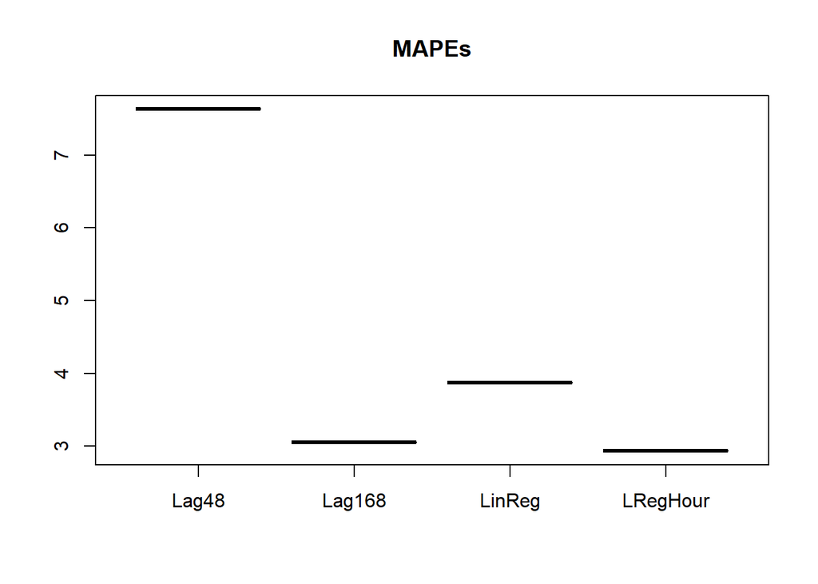

```r
boxplot(MAPE48,MAPE168,MAPEpartB,MEANofMAPESHourly, main= "MAPEs", names = c("Lag48","Lag168","LinReg","LRegHour"))
```